# Tarea 3

Mario Merchán

2023-01-19

## Paquetes y datos

```r
# Borramos
rm(list = ls())

# Paquetes
library(tidyverse)
library(tidyr)
library(ggplot2)
library(ggthemes)
marketing_data_cleaned <- read_csv(file = "marketing_data_cleaned.csv")
```

# Tarea 3

## ¿Qué campaña de marketing tiene más éxito?

```r
tabla1 <- marketing_data_cleaned |>
  pivot_longer(cols = c("AcceptedCmp1","AcceptedCmp2","AcceptedCmp3","AcceptedCmp4","AcceptedCmp5","Response"),names_to = "campaign", values_to = "campaign_purchase") |>
  filter(campaign_purchase == 1) |>
  count(campaign, sort = TRUE) |>
  mutate(porc = 100*n/sum(n))
tabla1
```

```
## # A tibble: 6 × 3
##   campaign         n  porc
##   <chr>        <int> <dbl>
## 1 Response       334 33.4
## 2 AcceptedCmp4   167 16.7
## 3 AcceptedCmp3   163 16.3
## 4 AcceptedCmp5   163 16.3
## 5 AcceptedCmp1   144 14.4
## 6 AcceptedCmp2    30  3.00
```

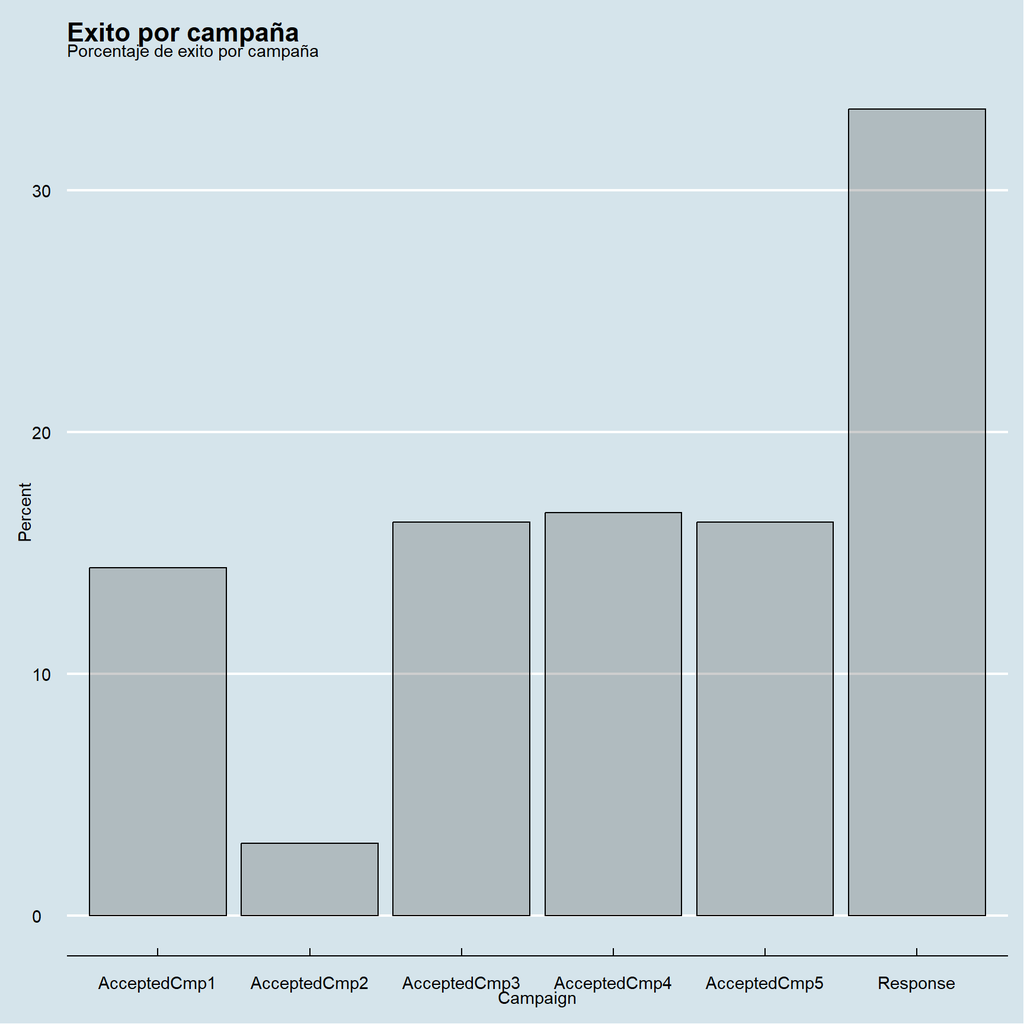

```r
ggplot(tabla1, aes(x = campaign, y = porc)) +
  geom_bar(stat = "identity", color = "black", alpha = 0.3) +
  scale_fill_brewer(palette = "Dark2") +
  labs(title = "Exito por campaña",
       subtitle = "Porcentaje de exito por campaña",
       x = "Campaign", y = "Percent") +
  theme_economist()
```

## ¿Cómo es el cliente promedio para esta empresa?

```r
tabla2 <- marketing_data_cleaned |>
  count(Marital_Situation, sort = TRUE) |>
  mutate(porc = 100*n/sum(n))
tabla2
```

```
## # A tibble: 2 × 3
##   Marital_Situation     n  porc
##   <chr>             <int> <dbl>
## 1 Couple             1442  64.6
## 2 Alone               791  35.4
```

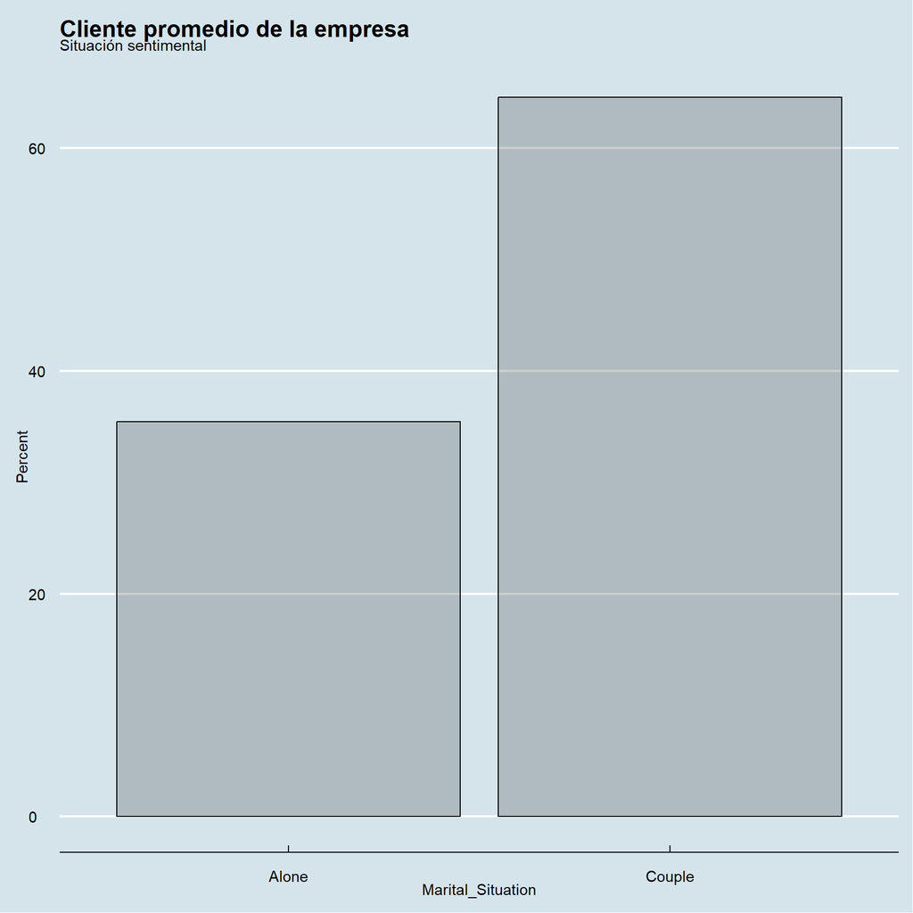

```r
ggplot(tabla2, aes(x = Marital_Situation, y = porc)) +
  geom_bar(stat = "identity", color = "black", alpha = 0.3) +
  scale_fill_brewer(palette = "Dark2") +
  labs(title = "Cliente promedio de la empresa",
       subtitle = "Situación sentimental",
       x = "Marital_Situation", y = "Percent") +
  theme_economist()
```

Si observamos la tabla 2 y su gráfico correspondiente podemos ver que el cliente promedio de la empresa tiende mucho más a tener pareja 64.58% mientras que el porcentaje de clientes que no tienen pareja es de 35.42%.Lo que significa que casi las 2/3 partes de los clientes son casados o viven en pareja.

```r
tabla3 <- marketing_data_cleaned |>
  count(Children, sort = TRUE) |>
  mutate(porc = 100*n/sum(n))
tabla3
```

```
## # A tibble: 4 × 3
##   Children     n  porc
##      <dbl> <int> <dbl>
## 1        1  1127 50.5
## 2        0   633 28.3
## 3        2   420 18.8
## 4        3    53  2.37
```

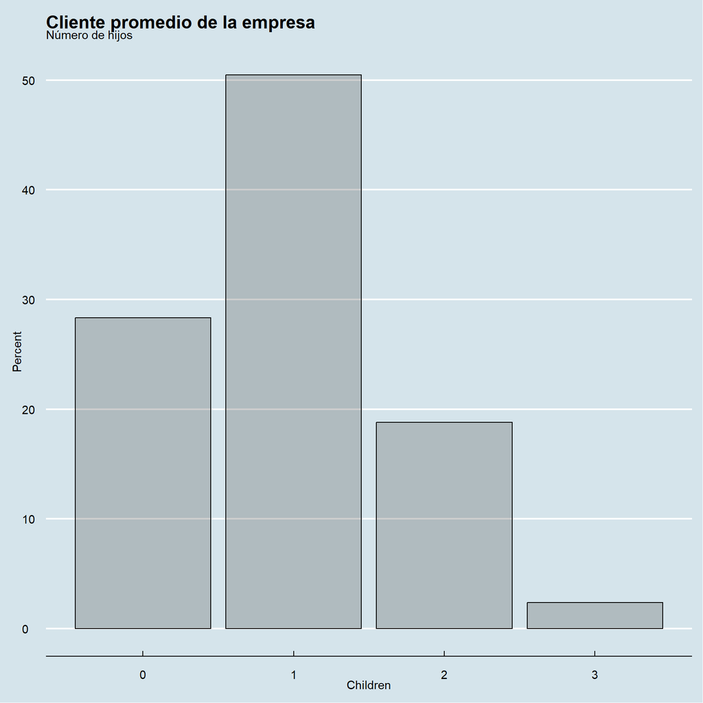

```r
ggplot(tabla3, aes(x = Children, y = porc)) +
  geom_bar(stat = "identity", color = "black", alpha = 0.3) +
  scale_fill_brewer(palette = "Dark2") +
  labs(title = "Cliente promedio de la empresa",
       subtitle = "Número de hijos",
       x = "Children", y = "Percent") +
  theme_economist()
```

Como se puede observar en la tabla 3 y en el gráfico el 50% de los clientes de la empresa tienen un solo hijo, el 28% no tienen hijos, el 18% llegan a tener 2 hijos y tan solo el 2.37% tienen 3 hijos. Por lo tanto la moda en la empresa es que los clientes tengan solamente 1 hijo.

```r
tabla4 <- marketing_data_cleaned |>
  count(Age_years, sort = TRUE) |>
  mutate(porc = 100*n/sum(n))
tabla4
```

```
## # A tibble: 52 × 3
##    Age_years     n  porc
##        <dbl> <int> <dbl>
##  1      38.8    89  3.99
##  2      43.8    86  3.85
##  3      39.8    82  3.67
##  4      42.8    79  3.54
##  5      36.8    77  3.45
##  6      44.8    77  3.45
##  7      41.8    73  3.27
##  8      49.8    73  3.27
##  9      45.8    71  3.18
## 10      40.8    69  3.09
## # … with 42 more rows
```

```r
marketing_data_cleaned |> summarise(min_age = min(Age_years), max_age = max(Age_years), mean_age = mean(Age_years), median_age = median(Age_years))
```

```
## # A tibble: 1 × 4
##   min_age max_age mean_age median_age
##     <dbl>   <dbl>    <dbl>      <dbl>
## 1    18.8    69.8     45.9       44.8
```

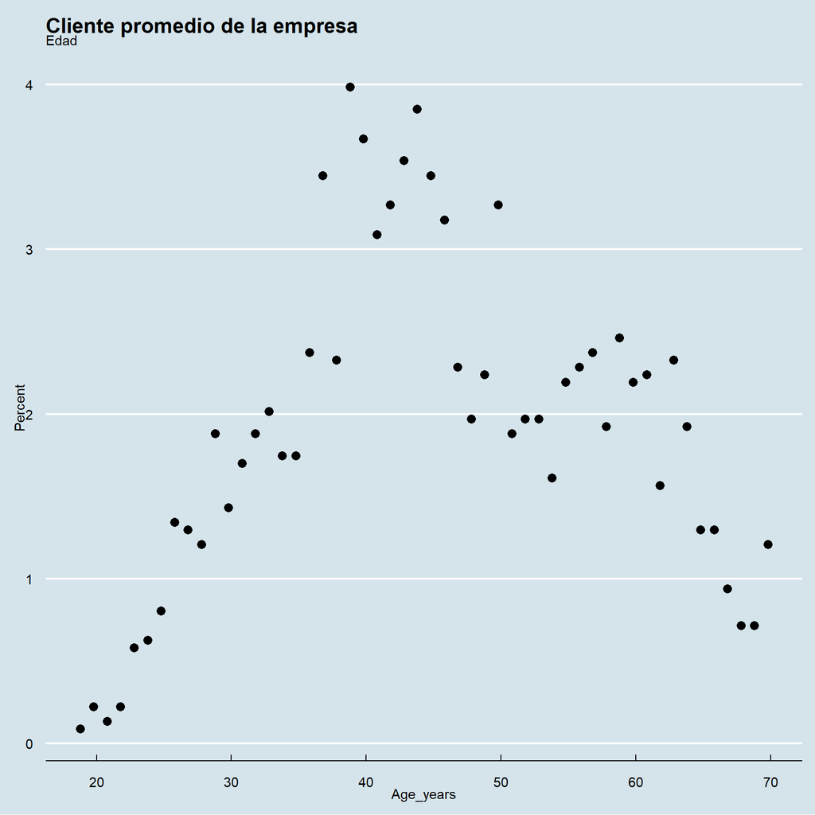

```r
ggplot(tabla4,aes(x = Age_years, y = porc )) +
  geom_point(color = "Black", size = 3) +
  scale_fill_brewer(palette = "Dark2") +
  labs(title = "Cliente promedio de la empresa",
       subtitle = "Edad",
       x = "Age_years", y = "Percent") +
  theme_economist()
```

Como se puede observar en el gráfico y en las estadísticas obtenidas, las edades de los clientes de la empresa van desde los 18 hasta los 69 años. La edad promedio es de 45.90 años y la mediana de la edad es 44,78 años. Y el rango de las edades más frecuente va desde los 36 hasta los 49 años.

```r
tabla5 <- marketing_data_cleaned |>
  mutate(Seniority_months = cut(Seniority_months, breaks = c(3, 6, 9, 12, 15, 18, 21, 24, 27), labels = c("3-6", "6-9", "9-12", "12-15", "15-18", "18-21", "21-24", "24-27"))) |>
  count(Seniority_months) |>
  mutate(porc = 100*n/sum(n))
tabla5
```

```
## # A tibble: 8 × 3
##   Seniority_months     n  porc
##   <fct>            <int> <dbl>
## 1 3-6                268  12.0
## 2 6-9                276  12.4
## 3 9-12               293  13.1
## 4 12-15              294  13.2
## 5 15-18              290  13.0
## 6 18-21              305  13.7
## 7 21-24              283  12.7
## 8 24-27              224  10.0
```

```r
marketing_data_cleaned |> summarise(min_seniority_months = min(Seniority_months), max_seniority_months = max(Seniority_months), mean_seniority_months = mean(Seniority_months), median_seniority_months = median(Seniority_months))
```

```
## # A tibble: 1 × 4
##   min_seniority_months max_seniority_months mean_seniority_months median_senio…¹
##                  <dbl>                <dbl>                 <dbl>          <dbl>
## 1                 3.19                 26.2                  14.8           14.9
## # … with abbreviated variable name ¹median_seniority_months
```

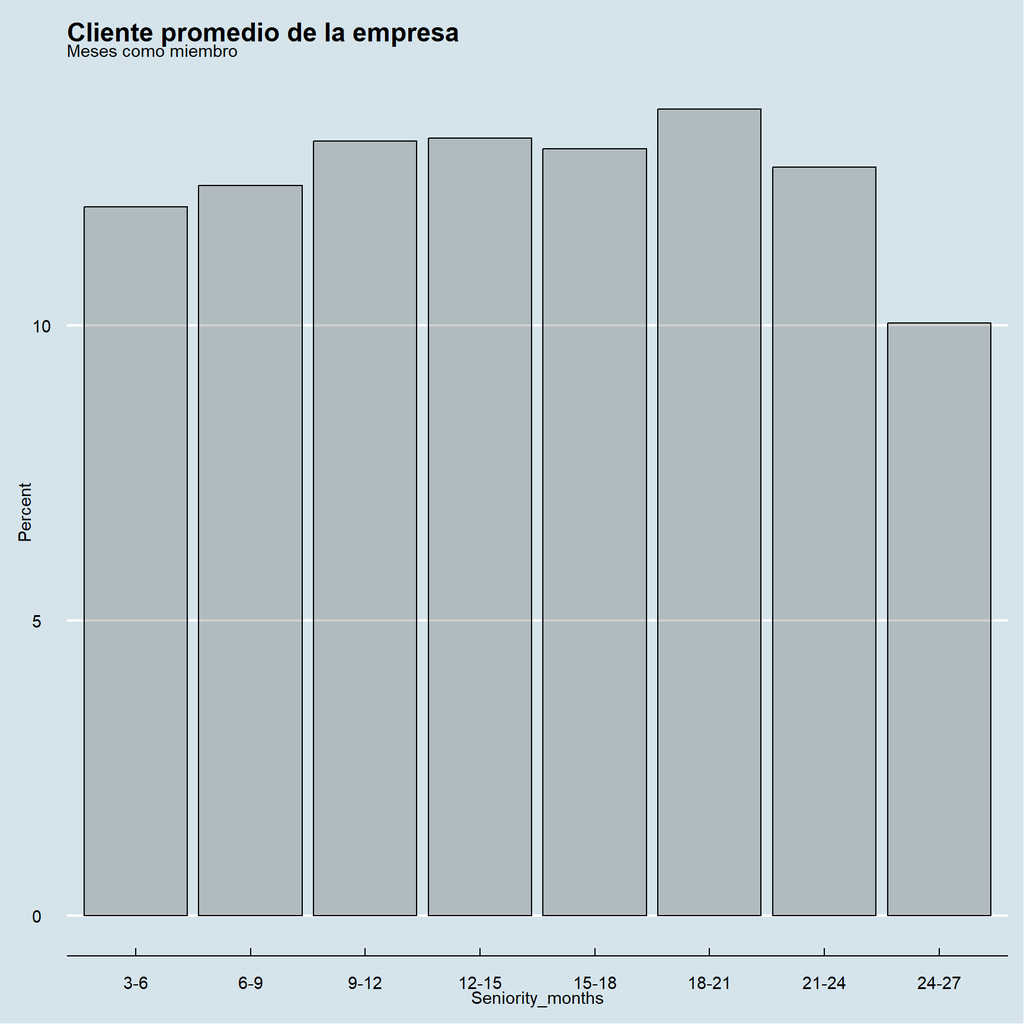

```r
ggplot(tabla5,aes(y = porc , x = Seniority_months )) +
  geom_bar(stat = "identity", color = "Black", alpha = 0.3) +
  scale_fill_brewer(palette = "Dark2") +
  labs(title = "Cliente promedio de la empresa",
       subtitle = "Meses como miembro",
       x = "Seniority_months", y = "Percent") +
  theme_economist()
```

Para determinar los meses en los que cada cliente pertenece como miembro de la empresa hemos agrupado por periodos de 3 meses cada uno, se pueden observar tamaños muy similares para cada grupo, lo que nos dice que la captación de clientes es bastante uniforme. El número de meses promedio como miembro de la empresa es 14.

```r
tabla6 <- marketing_data_cleaned |>
  count(NumPurchases, sort = TRUE) |>
  mutate(porc = 100*n/sum(n))
tabla6
```

```
## # A tibble: 32 × 3
##    NumPurchases     n  porc
##           <dbl> <int> <dbl>
##  1            4   202  9.05
##  2            6   191  8.55
##  3            5   180  8.06
##  4            3   128  5.73
##  5            7   128  5.73
##  6           18   104  4.66
##  7           14   100  4.48
##  8           16    98  4.39
##  9           17    89  3.99
## 10           21    86  3.85
## # … with 22 more rows
```

```r
marketing_data_cleaned |> summarise(min_NumPurchases = min(NumPurchases), max_NumPurchases = max(NumPurchases), mean_NumPurchases = mean(NumPurchases), median_NumPurchases = median(NumPurchases))
```

```
## # A tibble: 1 × 4
##   min_NumPurchases max_NumPurchases mean_NumPurchases median_NumPurchases
##              <dbl>            <dbl>             <dbl>               <dbl>
## 1                1               32              12.6                  12
```

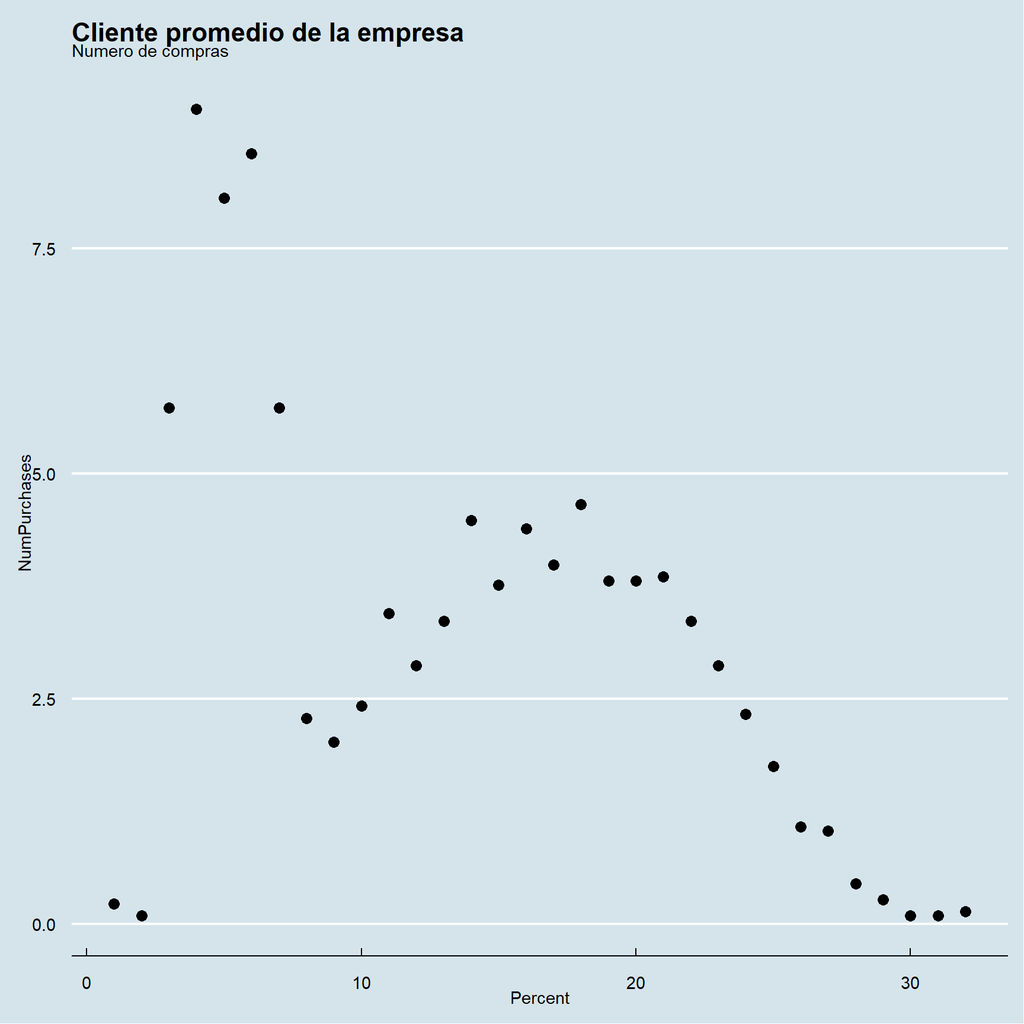

```r
ggplot(tabla6,aes(y = porc , x = NumPurchases )) +
  geom_point(color = "Black", size = 3) +
  scale_fill_brewer(palette = "Dark2") +
  labs(title = "Cliente promedio de la empresa",
       subtitle = "Numero de compras",
       x = "Percent", y = "NumPurchases") +
  theme_economist()
```

Si observamos el gráfico y la tabla 6, podemos ver que existe un mayor número de clientes cuando el número total de compras realizadas son 4, 5 y 6 compras y que pueden ser observados en los puntos más altos del gráfico. Por otro lado, El número de compras promedio por cliente es 12.57 y la mediana es 12 compras.

```r
tabla7 <- marketing_data_cleaned |>
  count(Family_Size, sort = TRUE) |>
  mutate(porc = 100*n/sum(n))
tabla7
```

```
## # A tibble: 5 × 3
##   Family_Size     n  porc
##         <dbl> <int> <dbl>
## 1           3   889 39.8
## 2           2   762 34.1
## 3           4   300 13.4
## 4           1   250 11.2
## 5           5    32  1.43
```

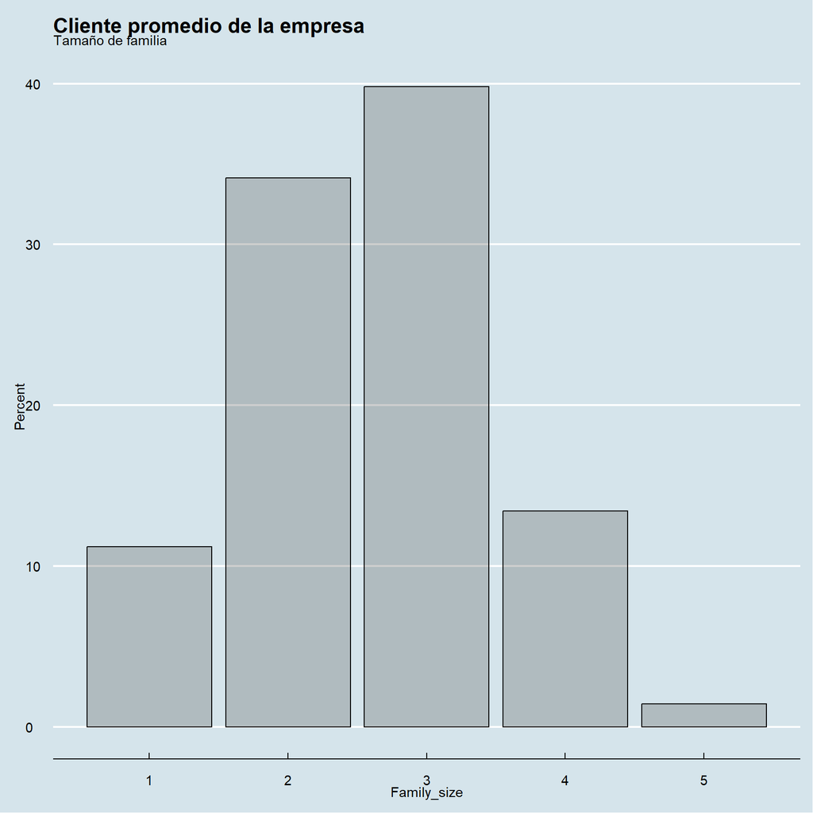

```r
ggplot(tabla7, aes(x = Family_Size, y = porc)) +
  geom_bar(stat = "identity", color = "black", alpha = 0.3) +
  scale_fill_brewer(palette = "Dark2") +
  labs(title = "Cliente promedio de la empresa",
       subtitle = "Tamaño de familia",
       x = "Family_size", y = "Percent") +
  theme_economist()
```

Observando la tabla 7 y su gráfico respectivo, podemos ver que el tamaño familiar que mas se repite es de 3 integrantes con un 39.81% seguido por familias de 2 integrantes con un 34.12%.

```r
tabla8 <- marketing_data_cleaned |>
  mutate(Income = cut(Income, breaks = c(0,15000, 30000, 45000, 60000, 75000, 90000, 105000), labels = c("0-15000", "15000-30000", "30000-45000", "45000-60000", "60000-75000", "75000-90000", "90000-105000"))) |>
  count(Income, sort = TRUE) |>
  mutate(porc = 100*n/sum(n))
tabla8
```

```
## # A tibble: 7 × 3
##   Income           n  porc
##   <fct>        <int> <dbl>
## 1 30000-45000    537 24.0
## 2 45000-60000    488 21.9
## 3 60000-75000    486 21.8
## 4 15000-30000    318 14.2
## 5 75000-90000    306 13.7
## 6 90000-105000    51  2.28
## 7 0-15000         47  2.10
```

```r
marketing_data_cleaned |> summarise(min_income = min(Income), max_income = max(Income), mean_income = mean(Income), median_income = median(Income))
```

```
## # A tibble: 1 × 4
##   min_income max_income mean_income median_income
##        <dbl>      <dbl>       <dbl>         <dbl>
## 1       2447     94194.      51810.         51369
```

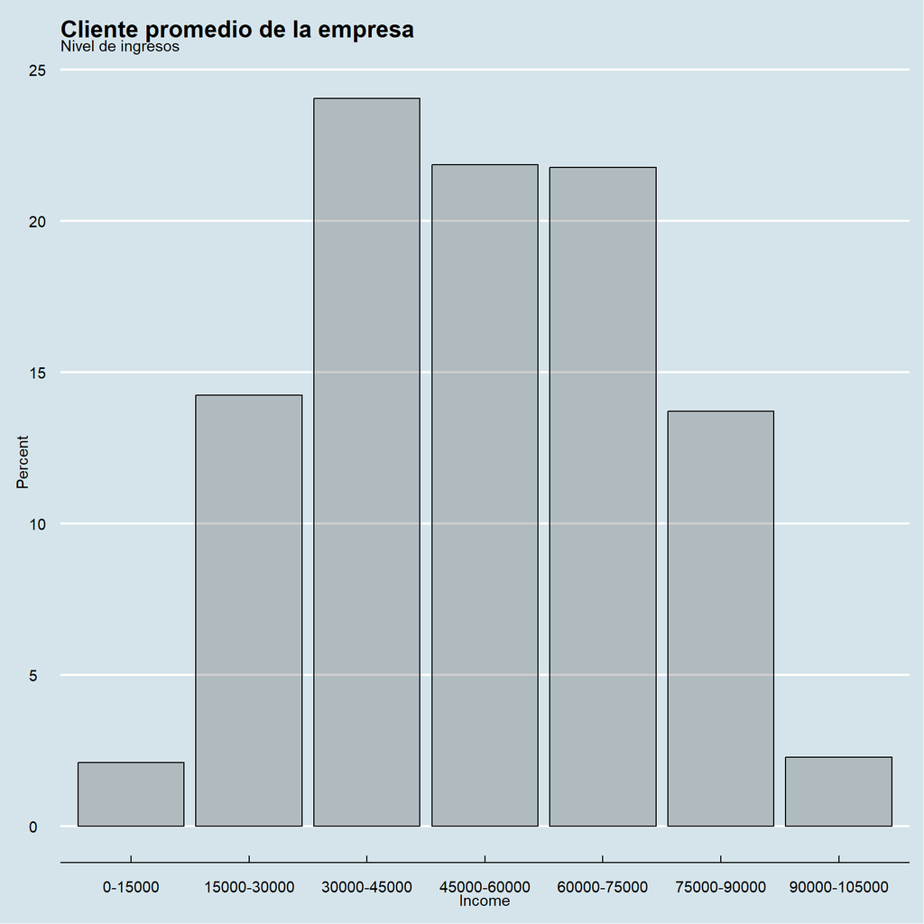

```r
ggplot(tabla8,aes(y = porc, x = Income )) +
  geom_bar(stat = "identity", color = "black", alpha = 0.3) +
  scale_fill_brewer(palette = "Dark2") +
  labs(title = "Cliente promedio de la empresa",
       subtitle = "Nivel de ingresos",
       x = "Income", y = "Percent") +
  theme_economist()
```

Ahora si analizamos la variable ingresos y observamos la tabla 8 y el grafico correspondiente podemos observar que los los clientes de la empresa tienden en mayor porcentaje a ganar entre 30000 y 45000 euros anuales (24.04%). Tenemos otros dos grupos de clientes que son de gran importancia con casi un 22% que son los clientes que ganan entre 45000 y 60000 y con un porcentaje similar los que ganan entre 60000 y 75000 anuales. Por otro lado, el ingreso anual promedio entre los hogares de los clientes de la empresa es de 51809.61 euros.

# ¿Qué productos están funcionando mejor?

```r
tabla9 <- marketing_data_cleaned |>
  pivot_longer(cols = c("MntFishProducts","MntMeatProducts","MntFruits","MntSweetProducts","MntWines", "MntGoldProds"),names_to = "Products", values_to = "Amount_spend") |>
  group_by(Products) |>
  summarize(Total_spend=sum(Amount_spend)) |>
  ungroup() |>
  mutate(porc = Total_spend*100/sum(Total_spend))
tabla9
```

```
## # A tibble: 6 × 3
##   Products         Total_spend  porc
##   <chr>                  <dbl> <dbl>
## 1 MntFishProducts        84045  6.19
## 2 MntFruits              58894  4.34
## 3 MntGoldProds           98601  7.27
## 4 MntMeatProducts       373893 27.6
## 5 MntSweetProducts       60605  4.47
## 6 MntWines              680730 50.2
```

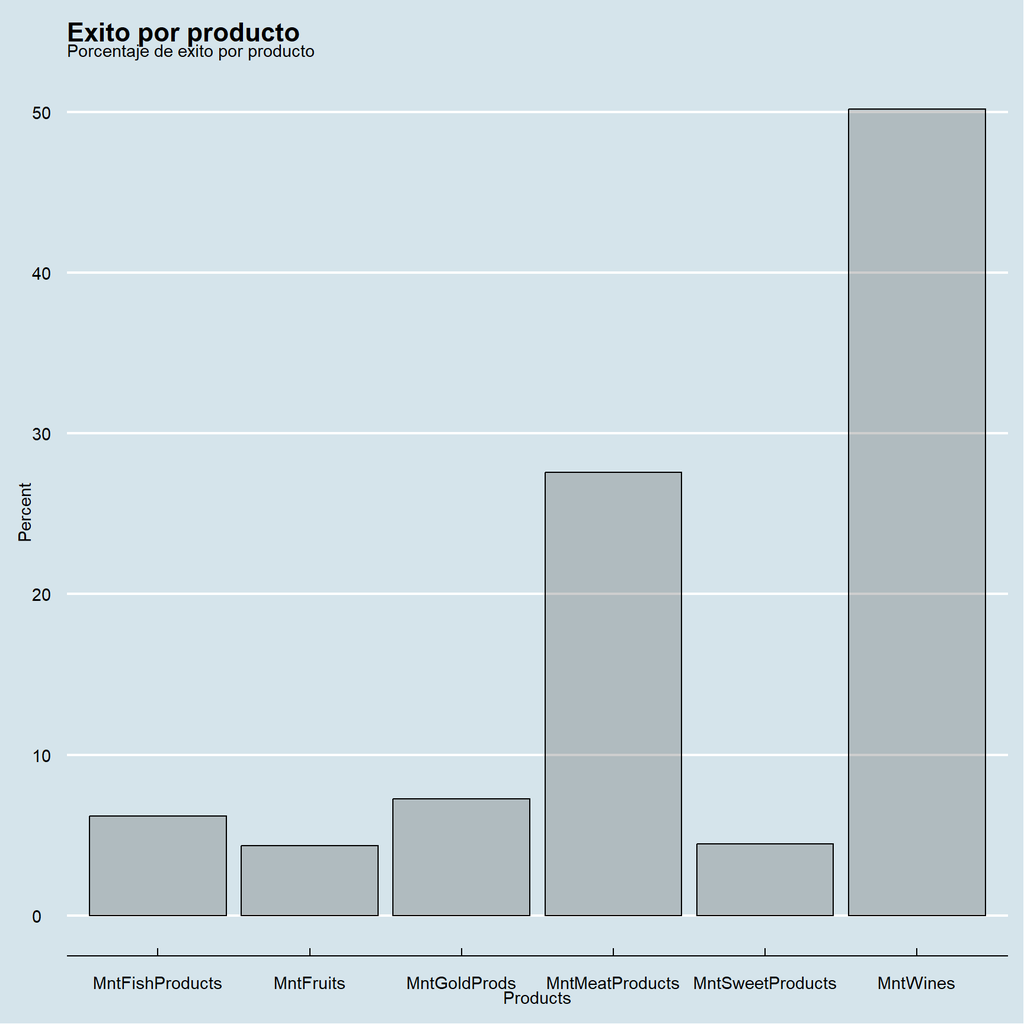

```r
ggplot(tabla9, aes(x = Products, y = porc)) +
  geom_bar(stat = "identity", color = "black", alpha = 0.3) +
  scale_fill_brewer(palette = "Dark2") +
  labs(title = "Exito por producto",
       subtitle = "Porcentaje de exito por producto",
       x = "Products", y = "Percent") +
  theme_economist()
```

# ¿Qué canales tienen un rendimiento inferior?

```r
tabla10 <- marketing_data_cleaned |>
  pivot_longer(cols = c("NumCatalogPurchases","NumStorePurchases","NumWebPurchases"),names_to = "Channels", values_to = "PurchasesPerChannel") |>
  group_by(Channels) |>
  summarize(Total_Purchases=sum(PurchasesPerChannel)) |>
  ungroup() |>
  mutate(porc = Total_Purchases*100/sum(Total_Purchases))
tabla10
```

```
## # A tibble: 3 × 3
##   Channels            Total_Purchases  porc
##   <chr>                         <dbl> <dbl>
## 1 NumCatalogPurchases            5962  21.2
## 2 NumStorePurchases             12970  46.2
## 3 NumWebPurchases                9150  32.6
```

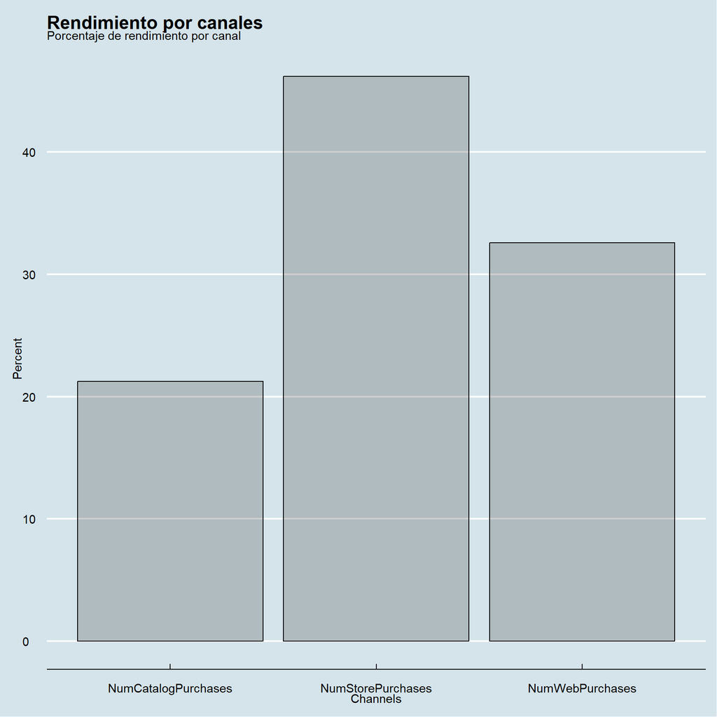

```r
ggplot(tabla10, aes(x = Channels, y = porc)) +
  geom_bar(stat = "identity", color = "black", alpha = 0.3) +
  scale_fill_brewer(palette = "Dark2") +
  labs(title = "Rendimiento por canales",
       subtitle = "Porcentaje de rendimiento por canal",
       x = "Channels", y = "Percent") +
  theme_economist()
```

La empresa maneja 3 canales de ventas que son: ventas por catalogo, ventas en tiendas fisicas, y ventas a través de la web. Si observamos la tabla 10 y su gráfico correspondiente, se puede ver que el canal con un rendimiento inferior es el de ventas por catalogo (NumCatalogPurchases) donde tan solo se ha vendido el 21.23% de las ventas de la empresa.